# Relationship Between Quantitative Variables

b06208001 龔泓愷

2018年12月7日

## Q312

```r
m_height = c(71,70,74,67,65,72,68,74)
f_height = c(60,66,65,66,67,63,69,63,61,65)
m_mid = c(64,64.5,72.5,64,63,69,67,69.5)
f_mid = c(63.5,67,65.5,69.5,67.5,65.5,70,63,63,67.5)
```

1. `Height` is the response variable(y)  
   `Mid-Parent Height` is the explanatory variable(x)

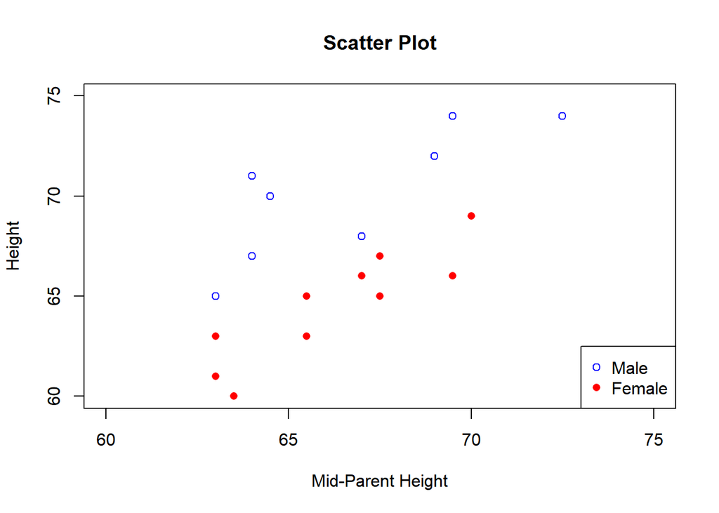

```r
plot(c(60, 75),type='n',xlim=c(60, 75), ylim=c(60, 75),
     xlab='Mid-Parent Height',ylab='Height',axes=T,
     main='Scatter Plot')
points(m_mid, m_height, pch = 1, cex = 1, col='blue')
points(f_mid, f_height, pch = 16, cex = 1, col='red')
legend("bottomright",c("Male","Female"),col=c("blue","red"),pch=c(1,16))
```

```r
m_diff = m_height - m_mid;m_diff
```

```
## [1] 7.0 5.5 1.5 3.0 2.0 3.0 1.0 4.5
```

```r
f_diff = f_height - f_mid;f_diff
```

```
##  [1] -3.5 -1.0 -0.5 -3.5 -0.5 -2.5 -1.0  0.0 -2.0 -2.5
```

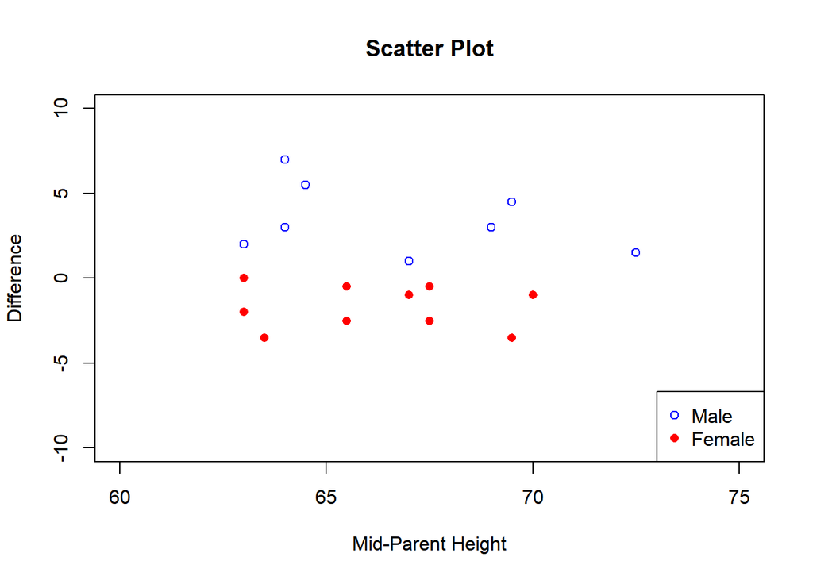

```r
plot(c(60, 75),type='n',xlim=c(60, 75), ylim=c(-10, 10),
     xlab='Mid-Parent Height',ylab='Difference',axes=T,
     main='Scatter Plot')
points(m_mid, m_diff, pch = 1, cex = 1, col='blue')
points(f_mid, f_diff, pch = 16, cex = 1, col='red')
legend("bottomright",c("Male","Female"),col=c("blue","red"),pch=c(1,16))
```

## Q324

1. `yhat = 126-2.34x`  
   The slope of the regrssion equation is `-2.34`.  
   The slope of `-2.34` means that whenever geographic latitudes(x) increases one unit,  
   the average January temperatures(y) decreases 2.34 degrees.
2. According to the table in exercise.9, the temperature of Pittsburgh and Boston is 25 and 29, respectively.  
   And the difference is 25 - 29 = -4.  
   By the regression equation, we calculate that the estimated difference is -4.68,  
   which is very close to the difference in the real world.

```r
diff = -2.34*2; diff
```

```
## [1] -4.68
```

3. 48.78 degrees.

```r
predict = 126 - 2.34 * 33; predict
```

```
## [1] 48.78
```

4. Phoenix is cooler than predicted.  
   On the other hand, Dallas is warmer.

```r
Phoenix_res = 43 - predict;Phoenix_res
```

```
## [1] -5.78
```

```r
Dallas_res = 54 - predict;Dallas_res
```

```
## [1] 5.22
```

## Q348

1. SSTO是由response variable(y)即反應變項與ybar計算而得，其與explanatory variable(x)解釋變項無關，故不管使用何者作為解釋變項，其SSTO值皆相同。
2. 從公式能知，SSR越高，在SSTO皆相同的情況下，計算而得的r.squred的值會越大，代表越能使用x來解釋y的變異。因此，在本題中，使用mid-parent heighty作為解釋變項，將能解釋最多的反映變項。
3. 計算r.square結果約為0.3099，代表使用father’s height將能解釋30.99%觀測值的身高變異。

```r
SSR = 88; SSE = 196
r.squre = SSR/(SSR + SSE); r.squre
```

```
## [1] 0.3098592
```

# Q362

1. `yhat = 113.6-1.01x`  
   The estimated average August temperature at the equator is 113.6 degrees.

```r
predict = 113.6 - 1.01 * 0; predict
```

```
## [1] 113.6
```

2. The regression equation is based on the dataset with latitude values range from 26 to 47 we have in exercise.9.  
   It should not be used to extrapolate the average August temperature of the equator which is 0 and is far below the range.

# Q382

1. `winning time = 272.63 - 0.1184 * year`  
   The correlation between the two variables is negative since the slope is `-0.1184`.  
   This means that winning time decreases over the years.
2. The predicted winning time(34.646) is shorter than the real one(34.91).

```r
win2010 = 272.63 - 0.1184 * 2010;win2010
```

```
## [1] 34.646
```

3. The slpoe indicates that the winning time decreases by 0.1184 seconds every year.  
   So a skater who wants to win should be faster than the last olympic game by `4*0.1184 = 0.4736` seconds.
4. Because there is no gurantee that this regression equation will be true in 2080 which is far beyound the dataset(1924~2006) we have.

```r
win2080 = 272.63 - 0.1184 * 2080;win2080
```

```
## [1] 26.358
```

## R Function Practice

```r
data <- read.csv("Vehicles.csv")
head(data)
```

```
##   Year Vehicle  GDP
## 1 1992 2907022 5615
## 2 1993 3238754 6205
## 3 1994 3570497 6784
## 4 1995 3874203 7397
## 5 1996 4146475 8037
## 6 1997 4411911 8717
```

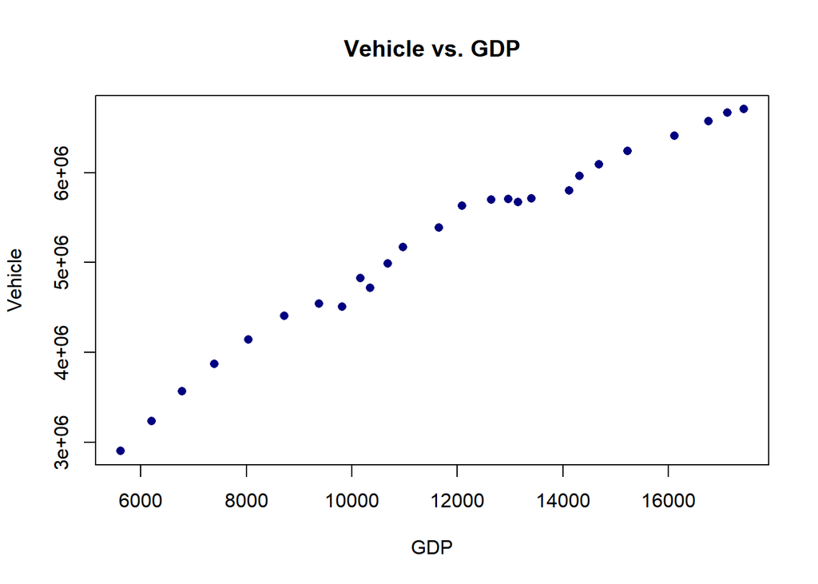

```r
#plot
plot(data$Vehicle ~ data$GDP,
     pch = 16, cex = 1, col = 'navy',
     main = 'Vehicle vs. GDP',
     xlab = 'GDP', ylab = 'Vehicle')
```

```r
#correlation
Cor = cor.test(data$Vehicle, data$GDP)
cor = Cor$estimate; cor
```

```
##     cor
## 0.98683
```

```r
#linear regression
RESULTS = lm(data$Vehicle ~ data$GDP)
summary(RESULTS)
```

```
##
## Call:
## lm(formula = data$Vehicle ~ data$GDP)
##
## Residuals:
##     Min      1Q  Median      3Q     Max
## -413891 -113513    3883  119749  334703
##
## Coefficients:
##              Estimate Std. Error t value Pr(>|t|)
## (Intercept) 1.606e+06  1.251e+05   12.84 3.06e-12 ***
## data$GDP    3.055e+02  1.022e+01   29.89  < 2e-16 ***
## ---
## Signif. codes:  0 '***' 0.001 '**' 0.01 '*' 0.05 '.' 0.1 ' ' 1
##
## Residual standard error: 175800 on 24 degrees of freedom
##   (1 observation deleted due to missingness)
## Multiple R-squared:  0.9738, Adjusted R-squared:  0.9727
## F-statistic: 893.2 on 1 and 24 DF,  p-value: < 2.2e-16
```

```r
coeff = RESULTS$coefficients; coeff
```

```
##  (Intercept)     data$GDP
## 1605510.4932     305.5035
```

```r
res = RESULTS$residuals; res
```

```
##           1           2           3           4           5           6
## -413890.617 -262405.679 -107549.203    8883.155   85632.918  143326.542
##           7           8           9          10          11          12
##   74049.221  -94902.799  -51560.169  116766.006  120742.678  214071.182
##          13          14          15          16          17          18
##  226221.791  334703.246  230943.828   11446.151   51239.045  138865.206
##          19          20          21          22          23          24
## -115501.338  -17788.512   -1116.323  -21755.224 -122004.803 -151697.564
##          25          26
## -169418.823 -227299.913
```

```r
yhat = RESULTS$fitted.values; yhat
```

```
##       1       2       3       4       5       6       7       8       9
## 3320913 3501160 3678046 3865320 4060842 4268584 4471439 4604333 4767777
##      10      11      12      13      14      15      16      17      18
## 4708815 4868593 4955662 5164626 5299659 5467380 5701396 5623187 5565447
##      19      20      21      22      23      24      25      26
## 5918914 5977877 6092440 6258634 6527783 6725444 6835425 6930742
```

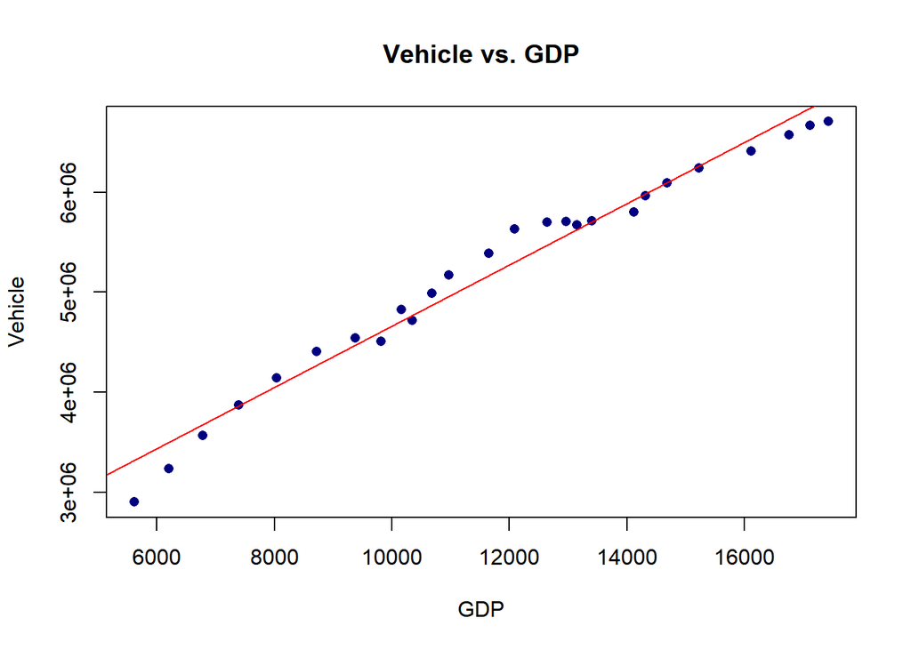

```r
plot(data$Vehicle ~ data$GDP,
     pch = 16, cex = 1, col = 'navy',
     main = 'Vehicle vs. GDP',
     xlab = 'GDP', ylab = 'Vehicle')
abline(RESULTS, col = 'red')
```

```r
#ANOVA
anova(RESULTS)
```

```
## Analysis of Variance Table
##
## Response: data$Vehicle
##           Df     Sum Sq    Mean Sq F value    Pr(>F)
## data$GDP   1 2.7609e+13 2.7609e+13   893.2 < 2.2e-16 ***
## Residuals 24 7.4185e+11 3.0910e+10
## ---
## Signif. codes:  0 '***' 0.001 '**' 0.01 '*' 0.05 '.' 0.1 ' ' 1
```

```r
SSR = 2.7609e+13
SSE = 7.4185e+11
r.squre = SSR/(SSR + SSE);r.squre
```

```
## [1] 0.9738332
```

1. Scatterplot  
   從散佈圖中，我們能看出兩者呈現高度正相關，Vehicle與GDP變動方向一致。
2. Correlation Coefficient  
   從前面的測試結果，可以看到兩者的相關係數為0.987，顯示兩者有高度正向關，與散布圖呈現內容相符。
3. Simple Regression  
   從線性回歸模型，我們能看到該回歸線的斜率與截距分別為305.5035與1605510.4932。  
   從yhat模型的估計值與實際值之間的殘差(SSE)，與回歸解釋的變異(SSR)，我們能算出r.square，其值為0.9738，  
   表示該回歸模型，GDP能解釋約97.4%Vehicle的變異。